# Computation Challenge AI & Satellite Image

```python
!pip install -r requirements.txt
```

```python
import geopandas as gpd
import rasterio as rio
from rasterio.plot import plotting_extent
from shapely import geometry
from shapely.geometry import mapping
from sklearn.cluster import DBSCAN

import numpy as np
import matplotlib.pyplot as plt
import matplotlib as mpl
from matplotlib.patches import Rectangle
import warnings

# To be able to plot raster image
import earthpy.plot as ep

np.set_printoptions(suppress=True)
np.set_printoptions(precision=8)
warnings.simplefilter(action='ignore', category=FutureWarning)
mpl.rcParams['figure.figsize'] = (14, 14)
mpl.rcParams['axes.titlesize'] = 20
```

```python
def get_coordinates(polygon):

    """

    Returns corner coordinates from a polygon

    Parameters
    ----------
    polygon : shapely.Geometry object

    """

    x = np.array(polygon.exterior.coords.xy[0])
    y = np.array(polygon.exterior.coords.xy[1])

    return np.array([x,y]).transpose()
```

```python
def bounding_box(coords):

    """

    Returns coordinates of bounding box surrounding polygons.
    Finds corner points of series of polygons by finding

    Parameters
    ----------
    coords : ndarray n x 2

    """

    min_x, min_y = np.min(coords[:,0]), np.min(coords[:,1])
    max_x, max_y = np.max(coords[:,0]), np.max(coords[:,1])

    return np.array([min_x, min_y,max_x,max_y])

def calculateSumArea(areas):
    sum = 0
    for area in areas.values():
        width = area[2] - area[0]
        height = area[3] - area[1]
        sum += width*height
    return sum


def plot_bbox(ax,coords):


    """

    Plot bounding box


    Parameters
    ----------
    coords : ndarray n x 4

    """


    for i in coords:
        x_min,y_min,x_max,y_max = i

        ax.fill([x_min,x_min,x_max,x_max,x_min], [y_min,y_max,y_max,y_min,y_min], fc=(0, 0.8549, 0, 0.5),
            edgecolor='red', linewidth=1, zorder=1)


def createPolygon(corners):

    """
    Returns Polygon

    Parameters
    ----------
    coords : ndarray corner points x,y (n x 2)

    """
    x_min, y_min, x_max, y_max = corners

    coordinates = np.array([[x_min,y_min],[x_min,y_max],[x_max,y_max],[x_max,y_min]])

    return geometry.Polygon(coordinates)


def bounding_box_poly(coords):

    """

    Returns coordinates of bounding box surrounding polygons.
    Finds corner points of series of polygons by finding

    Parameters
    ----------
    coords : ndarray n x 2

    """

    def corner_sides(polygon):
        """
        Returns maximum and minimum coordinates of the polygon
        """

        min_cor = np.min(polygon.exterior.coords.xy,axis=1)
        max_cor = np.max(polygon.exterior.coords.xy,axis=1)

        return np.vstack((min_cor,max_cor))


    stack = np.array(list(map(corner_sides,coords)))


    # Stack nx2x2 (number of polygons,min-max,x-y)
    # Stack[n,0,0] - Corresponds to minimum coordinate x of nth polygon
    # Stack[n,0,1] - Corresponds to minimum coordinate y of nth polygon

    # Stack[n,1,0] - Corresponds to maximum coordinate x
    # Stack[n,1,1] - Corresponds to maximum coordinate y

    min_x, min_y = np.min(stack[:,0,0]),np.min(stack[:,0,1])
    max_x, max_y = np.max(stack[:,1,0]), np.max(stack[:,1,1])

    return np.array([min_x, min_y,max_x,max_y])
```

```python
basepath = "data/"
shapefile = gpd.read_file(basepath + "clipped.shp")
shapefile.head(4)

with rio.open(basepath + "satellite.tif") as img:
    full_img = img.read()
    num_bands = img.count
```

## *Plot target polygons and the raster image*

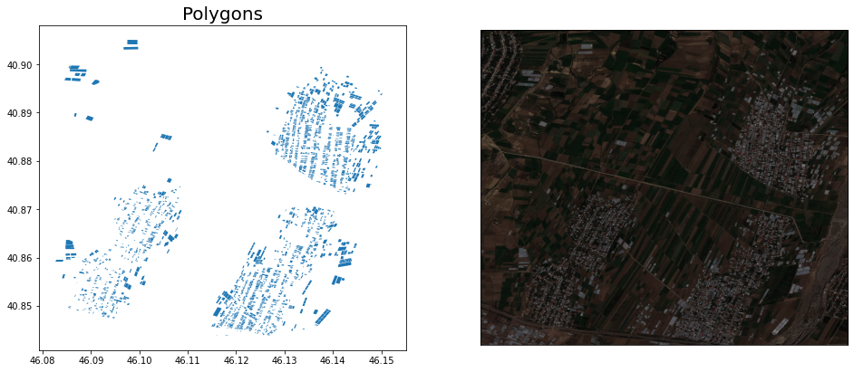

```python
fig,ax = plt.subplots(1,2,figsize=(16, 8))

ax[0].title.set_text('Polygons')
ax[1].title.set_text('Raster Image')

ep.plot_rgb(full_img,
            rgb=[0, 1, 2],
            ax=ax[1])

shapefile["geometry"].plot(ax = ax[0])
plt.show()
```

## Clustering

One can estimate the number of clusters needed by looking into either graph or raster image that we might need about 5 clusters to be able to partition the raster image to decrease computational cost and class imbalance. However, input raster images might differ by the number of groups of polygons. Hence, given that we do not know the number of groups in advance, it would be better to use cluster algorithms that do not require the number of clusters as a parameter. Therefore, density clustering algorithms are more suitable to solve this problem.

Density clustering algorithms use the concept of reachability i.e. how many neighbors have a point within a radius. DBScan is better for our problem because it doesn’t need a parameter, k, which is the number of clusters we are trying to find, which KMeans needs. DBSCAN produces a varying number of clusters based on the input data. DBSCAN requires only two parameters: epsilon and minPoints. Epsilon is the radius of the circle to be created around each data point to check the density and minPoints is the minimum number of data points required inside that circle for that data point to be classified as a Core point.

As input data I have used center coordinates of those polygons to decrease computational cost.

```python
# Extracted polygons from Geopandas series

polygons = np.array(shapefile["geometry"])

polygons_center = np.array(list(map(lambda P: P.centroid.coords[-1], polygons)))
```

As a minimum distance, $\epsilon$ = 0.003 and the minimum number of samples in each cluster min_samples = 4 returned satisfactory results.

```python
dbscan = DBSCAN(eps=0.003, min_samples=4).fit(polygons_center)

labels = dbscan.labels_
```

Disregarded the cluster № -1 from our dataset which contains the insignificant number of polygons inside

```python
shapefile["dbscan_cluster"] = labels
# Extracted number of clusters except -1
db_clusters = shapefile[shapefile["dbscan_cluster"] != -1]["dbscan_cluster"].unique()
```

```python
# Created a dictionary for each key(cluster) which contains values(coordinates of the bounding box)
dbscan_box_coordinates = {cluster: bounding_box_poly(shapefile[shapefile["dbscan_cluster"] == cluster]["geometry"].to_numpy()) for cluster in db_clusters}
```

### *Clustering algorithm have run on the vector file to group the polygons into different objects of interest*

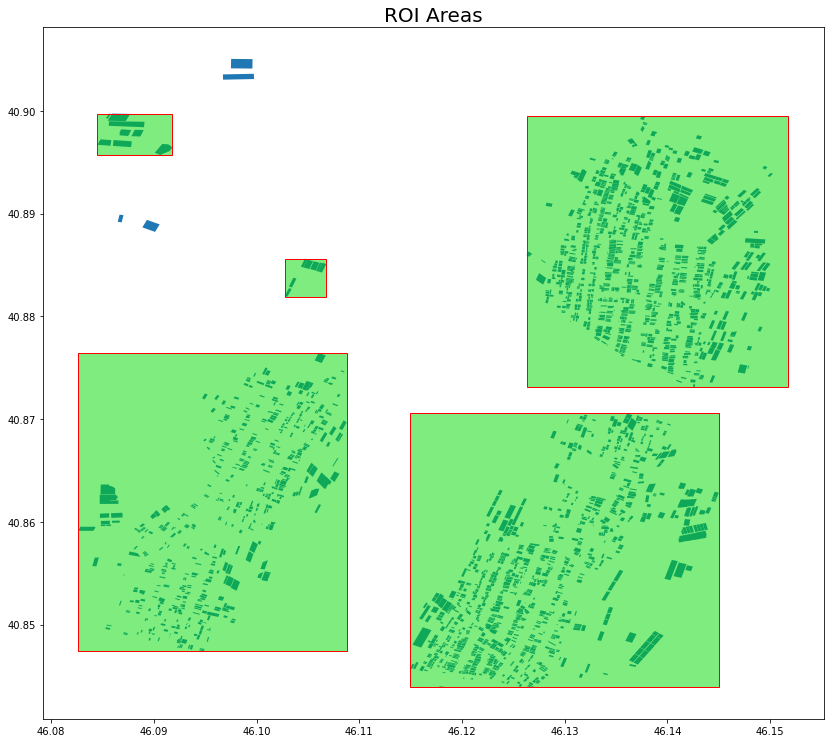

```python
fig, ax = plt.subplots()

shapefile["geometry"].plot(ax = ax)

plot_bbox(ax,dbscan_box_coordinates.values())

ax.title.set_text('ROI Areas')

plt.show()
```

```python
bounds = shapefile["geometry"].bounds
```

```python
boundries = bounds["minx"].min(), bounds["miny"].min(), bounds["maxx"].max(), bounds["maxy"].max()
```

```python
img_area = calculateSumArea({1: boundries})
```

```python
print("Number of bands in the image = ", num_bands)
```

```
Number of bands in the image =  4
```

```python
greenhouse = rio.open(basepath + "satellite.tif")

greenhouse_data = greenhouse.read()

# Project fire boundary to match NAIP data
greenhouse_bound = shapefile.to_crs(greenhouse.crs)

# Create plotting extent from DatasetReader object
greenhouse_plot_extent = plotting_extent(greenhouse)
```

## *Projecting clustered shapefiles and their ROI area on raster image*

```
Wall time: 0 ns
```

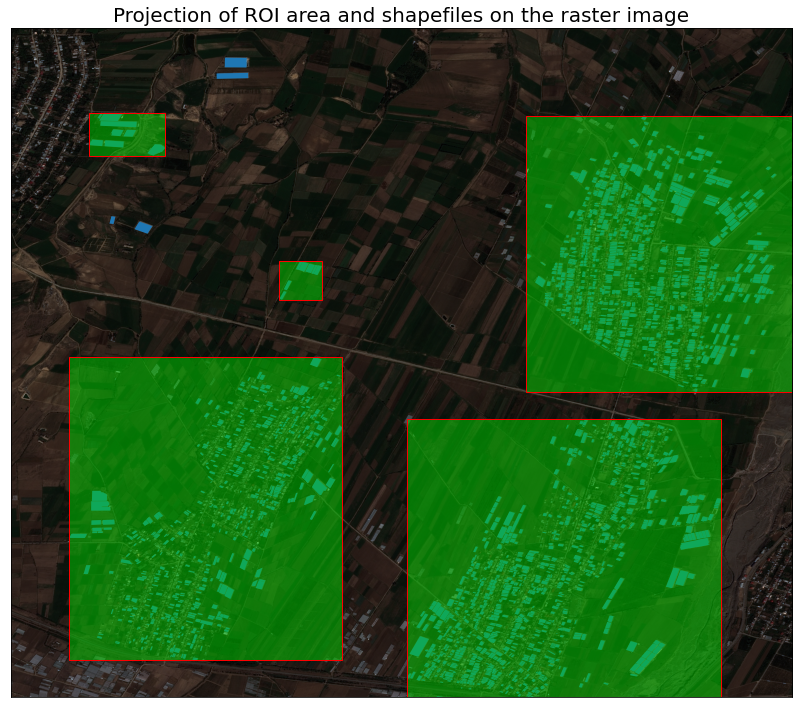

```python
%time
f, ax = plt.subplots()

ep.plot_rgb(greenhouse_data,
            rgb=[0, 1, 2],
            ax=ax,
            title="",
            extent=greenhouse_plot_extent)  # Use plotting extent from DatasetReader object



shapefile.plot(ax=ax)

plot_bbox(ax,dbscan_box_coordinates.values())

ax.set_title("Projection of ROI area and shapefiles on the raster image")

plt.show()
```

```python
dbscan_box_coordinates
```

```
{0: array([46.1149126 , 40.84388889, 46.14499848, 40.87055942]),
 1: array([46.12628472, 40.8730934 , 46.15176389, 40.8995077 ]),
 2: array([46.08450123, 40.89571872, 46.09179242, 40.89975099]),
 3: array([46.0826194 , 40.84741892, 46.10875776, 40.87645975]),
 4: array([46.1027278 , 40.88191664, 46.10678349, 40.88562597])}
```

```python
percentage_processed_after = (calculateSumArea(dbscan_box_coordinates) / img_area) * 100
```

```python
print(saved_percentage)
```

[output not shown]

```python
boxes = {cluster: createPolygon(coords) for cluster, coords in  dbscan_box_coordinates.items()}
```

```python
def export(raster,shapefile,coordinates):
    # Exporting Raster image and corresponding shape files

    # For each coordinate we generate new cropped raster files and corresponding shape files
    for cluster,coordinate in coordinates.items():

        geometries = [coordinate]

        out_image, out_transform = rio.mask.mask(greenhouse, geometries, crop=True)

        out_meta = img.meta

        out_meta.update({"driver": "GTiff",
                         "height": out_image.shape[1],
                         "width": out_image.shape[2],
                         "transform": out_transform})

        with rio.open(f"result/cropped_other_name_ROI_{cluster}.tif", "w", **out_meta) as dest:
            dest.write(out_image)


        shapefile_clipped = shapefile[shapefile["dbscan_cluster"] == cluster].drop("dbscan_cluster",axis=1)

        shapefile_clipped.to_file(f"result/cropped_ other_name_ROI_{cluster}.shp")

    print("Exporting is finished")
```

```python
%time
export(greenhouse,shapefile,boxes)
```

```
CPU times: user 2 µs, sys: 0 ns, total: 2 µs
Wall time: 4.05 µs
Exporting is finished
```

### Sample Cropped Raster Image and shapefile

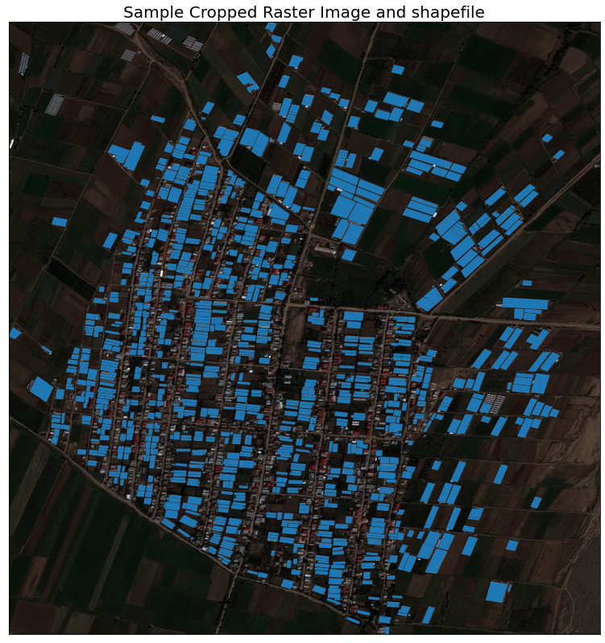

```python
shapefile = gpd.read_file("result/cropped_ other_name_ROI_1.shp")


with rio.open("result/cropped_other_name_ROI_1.tif") as greenhouse:
    full_img = greenhouse.read()
    greenhouse_bound = shapefile.to_crs(greenhouse.crs)
    # Create plotting extent from DatasetReader object
    greenhouse_plot_extent = plotting_extent(greenhouse)




f, ax = plt.subplots()

ep.plot_rgb(full_img,
            rgb=[0,1,2],
            ax=ax,
            extent=greenhouse_plot_extent)

shapefile.plot(ax=ax)
ax.set_title("Sample Cropped Raster Image and shapefile")
plt.show()
```